# Relatório da replicação do método de identificação por browser fingerprint

Seleção de atributos e K-vizinhos mais próximos

2026-06-26

# 1 Objetivo

Este relatório apresenta os dados necessários para comparar a replicação com o experimento descrito no artigo. O conjunto contém dez participantes anonimizados e seis coletas por participante. A avaliação utiliza validação leave-one-out, isto é, cada coleta é testada uma vez enquanto as demais formam a base de treinamento.

# 2 Leitura dos resultados

# 3 Visão geral

| Métrica | Valor |
| --- | --- |
| Participantes | 10 |
| Coletas | 60 |
| Coletas por participante | 6 |
| Features utilizadas | 9 |
| Valores de K avaliados | 9 |

# 4 Seleção de atributos

O artigo elimina atributos lentos, incompletos ou pouco discriminantes. O gráfico mostra a duração média dos componentes e a linha de 100 ms adotada no artigo.

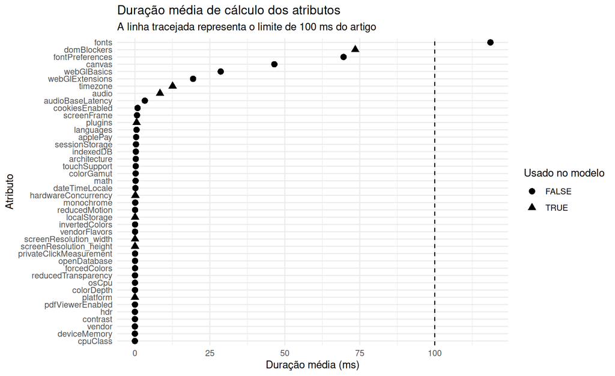

| Atributo | Duração média (ms) | Completo | Valores únicos | Probabilidade de coincidência |
| --- | --- | --- | --- | --- |
| audio | 8.3833 | TRUE | 6 | 0.3833 |
| domBlockers | 73.5000 | FALSE | 2 | 0.8167 |
| hardwareConcurrency | 0.1667 | TRUE | 3 | 0.6833 |
| localStorage | 0.0667 | TRUE | 1 | 0.9833 |
| platform | 0.0167 | TRUE | 4 | 0.3833 |
| plugins | 0.5833 | TRUE | 2 | 0.8833 |
| screenResolution_height | 0.0500 | FALSE | 7 | 0.3667 |
| screenResolution_width | 0.0500 | FALSE | 8 | 0.3667 |
| timezone | 12.5833 | TRUE | 3 | 0.3833 |

# 5 Probabilidade de autenticação por número de vizinhos

Este gráfico replica a ideia da Figura 2 do artigo. A probabilidade de autenticidade é a proporção dos K vizinhos que pertencem ao participante verdadeiro. A linha horizontal representa a fronteira de decisão de 0,5.

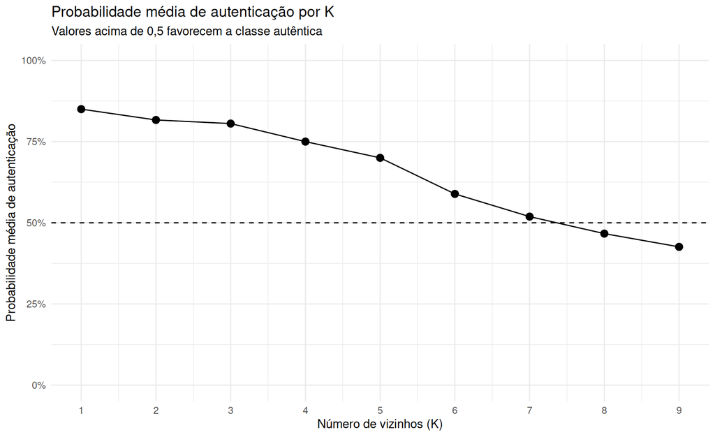

# 6 Acurácia de identificação por número de vizinhos

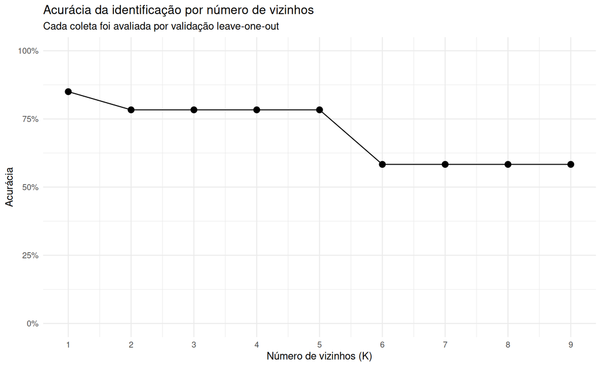

# 7 Resultado individual para K = 1

| Coletas | Acertos | Erros | Acurácia |
| --- | --- | --- | --- |
| 60 | 51 | 9 | 0.85 |

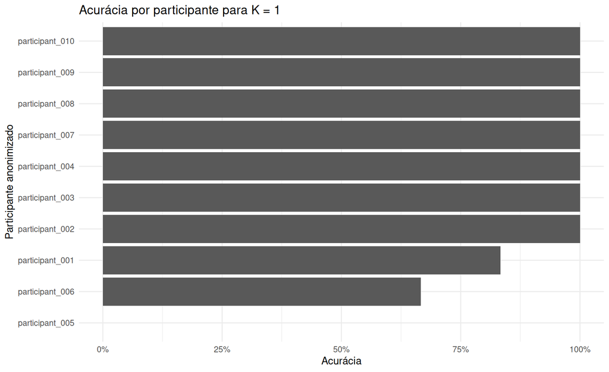

# 8 Matriz de confusão para K = 1

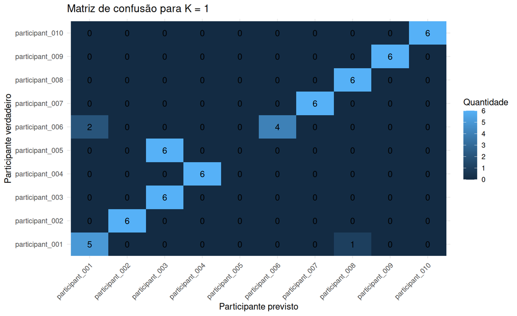

# 9 Dados exportados para comparação

Os arquivos CSV produzidos pelo pipeline permitem reproduzir todos os gráficos e comparar diretamente o comportamento observado com o artigo:

- `feature_selection.csv`: critérios de seleção de atributos;
- `knn_summary_by_k.csv`: probabilidade média, taxa de autenticação e acurácia para cada K;
- `knn_predictions.csv`: resultado de cada coleta em cada valor de K;
- `confusion_matrix_k1.csv`: matriz de confusão para K = 1;
- `selected_feature_values.csv`: tabela anonimizada das features utilizadas.

# 10 Conclusão automática

Foram avaliadas **60** coletas de **10** participantes anonimizados. Para K = 1, a acurácia foi de **85.0%**. O melhor resultado foi obtido com K = **1**, com acurácia de **85.0%** e probabilidade média de autenticação de **85.0%**.